# COMM-318 Final Project

```python
from IPython.display import display, HTML, IFrame
```

## Dear prospective COMM major,

Welcome to Penn!

The College of Arts & Sciences can be a fun, exciting, yet nerve-wracking place to spend four formative years. There's clubs to navigate, social circles to wade in and out of, and, of course, classes to choose.

Many of you may not know what you would like to study at all, let alone what to select as a major. That's okay! There are so many resources available to students to help make these important decisions. There's the [online catalog](https://catalog.upenn.edu/courses/) where you can find information on all sorts of Penn programs, majors, and minors, [Penn InTouch](http://pennintouch.apps.upenn.edu/) where you can search for classes being offered and register, and [Penn Course Alert](https://penncoursealert.com/) which will notify you by email and text message when a closed course opens.

Most critically, there is [Penn Course Review](https://penncoursereview.com/), or PCR as we'll affectionately call it. There are many reasons to love PCR: it gives you historical data on any Penn course that's been offered since 2002, including (sometimes) summaries of student comments. Students submit course reviews before receiving their course grades at the end of each semester, before they view their final grades; professors do not see their reviews until after they file their students' grades.

However, there are also some things missing from PCR that would be useful for students. While you can search for a particular course or professor, there is no way to evaluate an entire department. Similarly, there is no easy way to compare one potential major against another. There are also no visualizations to help users process course data in a more user-friendly way.

For prospective COMM majors, this poses a bit of a difficulty. How does the COMM major work? While still on Penn Course Review, the major is ["designed, administered, and instructed by the Annenberg School for Communication."](https://www.asc.upenn.edu/academics/undergraduate-program). So how do COMM courses actually perform on the 4-point PCR scale? And what considerations should you make as you decide if you should invest four years into studying COMM?

Not to fear! We've got your back and have done a lot of the legwork for you. Read on for some FAQs and some data answers!

### I heard Annenberg offers a summer term. What do I need to know about summer classes?

That is true! Like many departments in the College, COMM usually offers a set of courses each summer, including some courses that are also taught during the year. Courses last summer included "Communication Behavior," "Media Industries and Society," and "Children & Media."

Summer courses are not as big as spring or fall enrollments, but there is a historical average of around 10-15 students per class, with extremes as low as 3 and as high as 26. And some of the best courses offered in the summer have been taught recently: Visual Culture and Communication received top marks, for instance.

After [comparing](https://commjhub.asc.upenn.edu/user/coreymberman/notebooks/COMM318_Final_Project/data_analysis/2_Summer_classes.ipynb) summer with non-summer classes, we've found that students generally enjoy the summer courses a little bit more than non-summer.

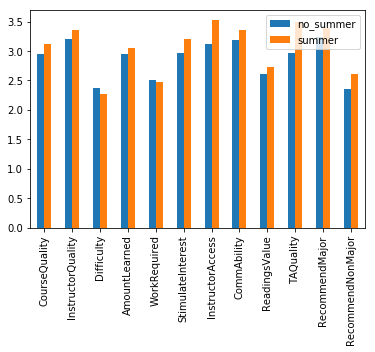

As you can see above, course ratings for most of the variables are preferable in the summer (albeit, because the 0-4 scale is so small, the effect sizes are small as a result). Courses are even often slightly less difficult during the summer, which is a nice bonus.

We know what you're thinking! You might also be looking at some required COMM classes and be wondering if it pays to take specifically those in the summer. Take a look at the mean course qualities for the following classes that are offered in both summer and non-summer terms:

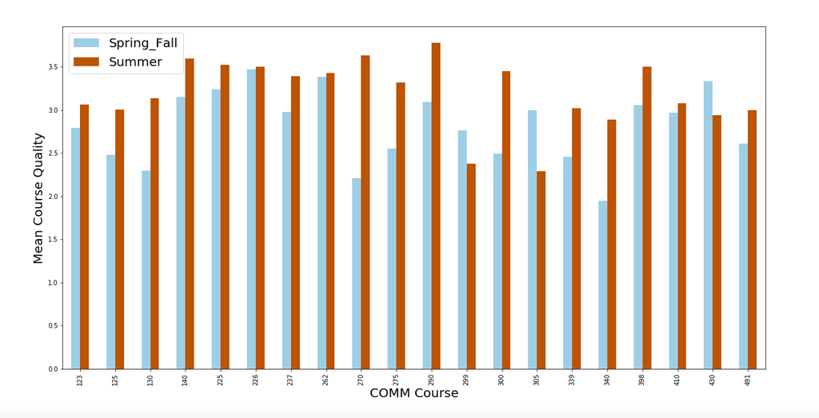

So there are indeed times when it pays to take the summer version of a class. Similar analyses could do the same with other variables, like instructor quality or amount learned.

### Cool. So what is the deal with the breakdown of the major? There are requirements based on course level?

That's right! Every COMM major is expected to take two intro-level courses which are labeled 125, 130, and 123, as well as four courses from the 200-level, and four from the 300+ range. Then there are cognate requirements from other requirements, but that is another story.

Somewhat surprisingly, there is not a big difference between ratings for the four levels. We would have thought that upper level classes would be dramatically higher, but the differences are relatively small. We do see a big jump in course quality from 100 to 200 level, and a big jump in work required from 300 to 400 level, but most other data is relatively stable.

[figure not shown]

Here's the data that went into that, if you're looking for more:

#### Mean course ratings by hundred-level COMM classes:

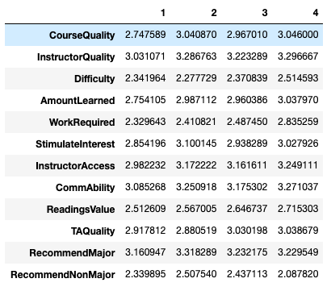

Long story short: if you decide to major in COMM, your classes' course quality will likely go up a bit, as will instructor quality, amount learned, and work required, among others. This is not unlike other departments.

Something to note is that there is a bit of a drop in most categories' averages in the 300-level range. On average, the 200-level courses are seemingly more popular. However, please remember that these are just aggregated means - there are plenty of very popular 300-level courses including COMM 318, "Stories from Data!"

Just another reason to check out PCR before making your course selections.

### Thanks for the heads up. I feel like Course Quality and Instructor Quality are the most important criteria though, no? What is the best COMM class I can take?

That's a bit of a loaded question.

When it comes down to it, there are many criteria you can and should use to select classes. Some might even be totally out of your control, like scheduling conflicts! But if you truly only care about Course and Instructor Quality ratings, we could use an [interactive bubble plot](https://commjhub.asc.upenn.edu/user/coreymberman/notebooks/COMM318_Final_Project/data_analysis/3_Course_levels.ipynb) to find this information.

Considering those criteria, the best courses for you might be Visual Culture and Communication, Contemporary Black Women Artists, or Conventions Campaigns and Debates. Of course, this is still subject to professor availability!

```python
IFrame('plot3.html', width=800, height=600)
```

[interactive chart not shown]

### Talk to me about the professors.

Here you're in luck. There are many Annenberg professors who are leaders in their fields and are fantastic instructors in addition to their accomplishments in research.

One thing that many students are confronted with when choosing classes is which section of a given course to sign up for. In the Economics department, for example, there are often professors teaching 9am, 10am, and 11am sections of the same course. There have even been up to 6 sections of a given ECON course taught within a given semester!

And [the statistics don't lie](https://commjhub.asc.upenn.edu/user/coreymberman/notebooks/COMM318_Final_Project/data_analysis/4_Professors_teaching_multiple_sections.ipynb): mean course quality, instructor quality, and amount learned can and do vary across sections, even when taught by the same professor. Some professors improve as the day goes on, and some not - it's a case-by-case basis. It's also one of those hidden trends in the course data that you wouldn't necessarily get from a cursory glance at PCR.

The good news is, the data shows that this doesn't really happen in COMM classes, so this is not really something that you will have to worry about! COMM professors rarely teach multiple courses in a semester, so your class will likely have their attention.

### My mom's neighbor's cousin's ex-husband was a COMM major at Penn and gave me some recommendations. Are there objectively "best" courses to take?

It's hard to say anything is "objective" when so much of course reviewing and enrollment is based on student preference.

But here's something you won't find on Penn Course Review: [we punched the numbers](https://commjhub.asc.upenn.edu/user/coreymberman/notebooks/COMM318_Final_Project/data_analysis/5_all_star_classes.ipynb) and calculated the highest-rated COMM courses along some key dimensions. In recent years these classes have topped the charts (and keep in mind that "A" is for spring semester, "B" for summer, and "C" for fall):

#### Highest rated COMM courses each semester:

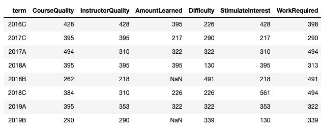

If you're the kind of student who likes to take classes that are particularly memorable or highly-regarded, this data will be very useful for you. Last spring, for instance, COMM-322 had the highest amount learned, but COMM-395 had best course quality.

Last word on this: don't be afraid to take classes with newer professors, too! This kind of analysis we've done is inherently more inclined to reward professors who've been around for a while, but every legendary class was first taught sometime.

### That sounds pretty cool. But not every class can be a "legendary" class. Are the majority of COMM classes well-rated?

We're glad you asked.

For convenience, we'll designate a 3.00 or higher as "well-rated" (including high on difficulty and work required).

Based on that metric, [we find](https://commjhub.asc.upenn.edu/user/coreymberman/notebooks/COMM318_Final_Project/data_analysis/9_Proportions_over_3.ipynb) that among COMM classes in the available data:

- 55% of sections receive 3 or higher for Course Quality
- 71% of sections receive 3 or higher for Instructor Quality
- 50% of sections receive 3 or higher for Amount Learned
- 12% of sections receive 3 or higher for Difficulty
- 56% of sections receive 3 or higher for Ability to Stimulate Interest
- 17% of sections receive 3 or higher for Work Required

For reference, here's how those numbers compare to other social sciences that students often choose besides COMM:

#### Percentage of course rated higher than 3:

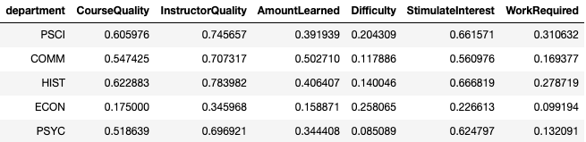

COMM actually has the highest proportion of courses given over a 3 for amount learned, whereas Political Science has the highest for work required. (ECON did not perform too well.)

### On the subject of other departments, how do they compare over time? Is one better recently?

That's a great question. A lot of students are deciding, for instance, between a Political Science major and a Political Communication concentration. We [took a look](https://commjhub.asc.upenn.edu/user/coreymberman/notebooks/COMM318_Final_Project/data_analysis/8_Majors_comparison.ipynb).

```python
IFrame('plot4.html', width=800, height=600)
```

[interactive chart not shown]

As you can see, the course qualities by department generally have been recently hovering between 2.9 and 3.2, not a very large range. Except ECON, which has been much lower on average course quality for some time.

Generally, History and Political Science have been very highly regarded in terms of Course Quality, with Communication a close contender and Psychology a little behind.

You could also look at these departments' courses as discrete items, in which case you could correlate course and instructor quality as follows:

```python
IFrame('plot5.html', width=800, height=600)
```

[interactive chart not shown]

There's a lot going on there, but we can see that the psychology courses and economics courses are very numerous and are taken by lots of individual students, while political science and communication are smaller departments. Having said that, economics courses are generally lower on the spectrum and history, communication, and political science are higher up.

To make things a bit less messy, we can separate those bubbles out by department:

```python
IFrame('plot6.html', width=800, height=600)
```

[interactive chart not shown]

```python
IFrame('plot6.html', width=800, height=600)
```

[output not shown]

We also see from these columns some really clean correlations between Course and Instructor Quality, confirming that the two really are linked in many ways.

Bottom line: choose your classes carefully! The departments all offer different classes, and you should try some that have great ratings and look interesting to you.

### Okay, zooming back out to just COMM. How stable have the ratings averages been over time?

Pretty stable.

[Looking at review categories over time](https://commjhub.asc.upenn.edu/user/coreymberman/notebooks/COMM318_Final_Project/data_analysis/6_Change_over_time.ipynb), there have been some spikes but overall we find that there is a general order for how COMM courses are rated. Average instructor quality is typically highest, and difficulty lowest.

Interestinly, until about the years 2012-2013, course qualities were on average higher than amount learned, but that has flipped recently.

Another clear finding is that certain pairs of variables "follow" each other in peaks and valleys, showing they are tightly correlated. Specifically, course quality and amount learned are pretty tied, and difficulty and work required show the same pattern.

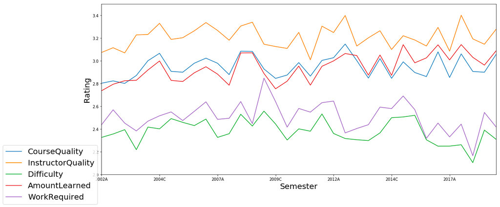

### What about other students' preferences? How popular are COMM classes?

Another excellent question.

Recently, there have been somewhere around 600-700 seats filled in COMM classes each semester. This is not the biggest department in the school, but that is still substantial.

We can further [break that down](https://commjhub.asc.upenn.edu/user/coreymberman/notebooks/COMM318_Final_Project/data_analysis/7_Students.ipynb) by semester over time:

```python
IFrame('plot7.html', width=800, height=600)
```

[interactive chart not shown]

We see some unevenness historically, but analysis shows that there have not been corresponding jumps in the number of courses offered.

It is possible that preferences for particular professors drove this change. Specifically, when looking at the courses offered in Fall 2008, we see a number of big lectures taught by more popular COMM professors, which might explain the big jump in the graph at that point.

While these big jumps are possible, you should expect that somewhere around 600 or 700 students will take COMM each semester, and that the department has a solid grasp of enrollment numbers at this point.

### Is this analysis fool-proof?

We would not go that far.

Course rating data is instructive, but imperfect. For one thing, data pulled from the Penn Course Review API is only analyzable in the confines of the 0-4 scale along which PCR lists reviews.

Of course, course review data is self-selecting and self-reporting, which opens the door for biases of other kinds. Most Penn students will at some point take a class in which they disagree with the majority of their classmates as to the instructor quality or difficulty. Moreover, there are other potential biases that have been well-documented by resources such as the [Daily Pennsylvanian](https://projects.thedp.com/2016/04/PCR/article/biases-in-pcr-data.html).

Having said all that, PCR data is the best we have, and it is so widely used that gleaning insights and stories from this data is a useful way to approach course and major selection. And the fact that we have the data available since 2002 for all Penn courses means that, as the number of reviews increases, it becomes more and more reliable and statistically significant for analysis. While it isn't fool-proof, it's a really good indicator.

### Is there anything else I should know?

Have fun!

COMM is a great department with lots of interesting courses. You should definitely give it a shot if you are seriously considering the major.

Even if you are not, there are some classes in the department that are definitely worth taking even as electives or to fulfill another requirement.

The best recommendation we can make is to keep using PCR. It is a great resource, and some universities do not have something comparable at all.

Finally, although its analysis is good, PCR data's usefulness can be enhanced through further data analysis and looking for more stories in the data. Future analyses can and should look at more data stories, such as how tenure status affects teaching quality, how many classes are filled to capacity and how that may correlate with course ratings, and whether instructor quality varies with instructor educational background. These are just a taste of future lines of inquiry that can be undertaken.

In the meantime, hopefully this guide has helped you strategize around your four years at Penn and has lent some insight into the real stories behind Communication course data.

There is much to explore -- good luck!